# time-varying N-body simulation

## 5 Make three plots summarizing the results

```
the first plot should have time on the horizontal axis, and show the 𝑥 positions of both particles on the vertical axis. Estimate the period of orbit by eye; does this make sense?

the second plot should show the trajectories that the particles trace out in the 𝑥-𝑦 plane. The Earth’s orbit should be pretty close to a perfect circle. Scale the axes so it appears this way.

the third plot should show the 𝑥 velocity of the Sun as a function of time. Based on this plot, to what precision would we need to measure the radial velocity of a Sun-like star to see an Earth-like planet orbiting it? (Estimate this by eye.)
```

For all positions and times, convert back to AU and days for the above plots.

### 5.1 first plot x vs time

```python
print(type(time))
positions = np.array(position) #converting the position list from the calculateTrajectories function to a numpy array
xpos_earth = position_array[:, 0, 0] #geting all of the x positions of the earth from the positions array
xpos_sun = position_array[:, 1, 0] #geting all of the x positions of the earth from the positions array

print(f"len of time array: {len(time_array)}")
print(f"len of xpos_earth array: {len(xpos_earth)}")
print(f"len of xpos_sun array: {len(xpos_sun)}")
```

```
<class 'list'>
len of time array: 407
len of xpos_earth array: 407
len of xpos_sun array: 407
```

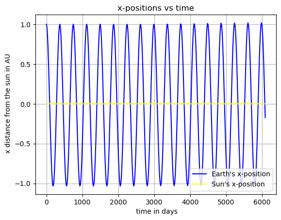

```python
plt.plot(time_array/(24*60*60), xpos_earth, color = "blue", label="Earth's x-position")
plt.plot(time_array/(24*60*60), xpos_sun, color = "yellow", label="Sun's x-position")
plt.xlabel(" time in days")
plt.ylabel(" x distance from the sun in AU")
plt.title("x-positions vs time")
plt.legend()
plt.grid()
```

Well, this graph looks correct as it shows Earth's x position as a cosine wave as a function of time with a period of about 365 days!

### 5.2 Second plot trajectories on x-y plane

```python
xpos_earth = position_array[:, 0, 0] #geting all of the x positions of the earth from the positions array
ypos_earth = position_array[:, 0, 1] # getting all of the y positions of the earth from the positions array
xpos_sun = position_array[:, 1, 0] #geting all of the x positions of the earth from the positions array
ypos_sun = position_array[:, 1, 1] #geting all of the y positions of the earth from the positions array
```

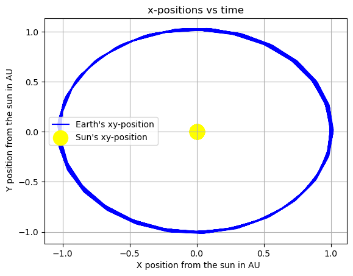

```python
plt.plot(xpos_earth, ypos_earth, color = "blue", label="Earth's xy-position")
plt.scatter( xpos_sun, ypos_sun, s=300, color = "yellow", label="Sun's xy-position")
plt.xlabel("  X position from the sun in AU")
plt.ylabel(" Y position from the sun in AU")
plt.title("x-positions vs time")
plt.legend()
plt.grid()
```

### 5.3 third plot x velocity of sun vs time

```python
xvelocity_sun = velocity_array[:, 1, 0] #geting all of the x velocities of the earth from thevelocity array
```

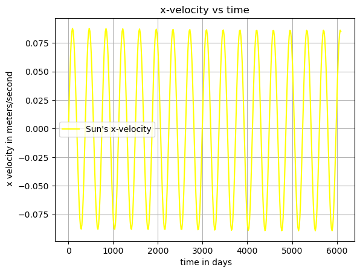

```python
plt.plot(time_array/(24*60*60), xvelocity_sun, color = "yellow", label="Sun's x-velocity")
plt.xlabel(" time in days")
plt.ylabel(" x velocity in meters/second")
plt.title("x-velocity vs time")
plt.legend()
plt.grid()
```

## 6 Repeat the Earth-Sun calculation and plots

starting from the same initial conditions but (with python) decreasing the initial velocities by a factor of 2. How does the orbit change?

I cannot figure out how to do this

## 7 Read in the initial conditions describing the Kepler-16ABb circumbinary planet system

Stored in the file kepler16.txt on Canvas. The file contains 7 columns: one for masses, three for positions, and three for velocities. Read in the data file and organize these initial conditions into arrays that could be fed as inputs to your calculateTrajectories function

This is quite simple. I will read the files from Canvas, sort the data, and then input that data into my calculateTrajectories function

```python
import pandas as pd # I'm going to use pandas to read the kepler-16.txt file
```

```python
file = 'kepler16.txt'
row = 4

mass = [] #kg
x = [] #meters
y = [] #meters
z = [] #meters
vx = [] # m/s
vy = [] # m
vz = [] # m/s

for rows in range(row-1): #reading the data skipping over the first 8 rows of header


    single_row = pd.read_csv(file, skiprows=rows + 1, nrows=1, header=None) ##assinign a single row to this list
    #print(single_row[0][0])
    #print(single_row[0][0][72:83]) #checking to make sure the indices are correct


    #use slicing to get each value out that's separated by a space

    mass.append(single_row[0][0][0:11]) # assigning the first element of the row as the mass
    x.append(single_row[0][0][12:23]) #assigning the second element of the row to x(m)
    y.append(single_row[0][0][24:36]) #assigning the third element of the row to y(m)
    z.append(single_row[0][0][36:47]) #assigning the fourth element of the row to z(m)
    vx.append(single_row[0][0][48:59]) #assigning the second element of the row to vx(m/s)
    vy.append(single_row[0][0][60:71]) #assigning the third element of the row to vy(m/s)
    vz.append(single_row[0][0][72:83]) #assigning the fourth element of the row to vz(m/s)


# converting the list to numpy arrays
mass = np.array(mass)
x = np.array(x)
y = np.array(y)
z = np.array(z)
vx = np.array(vx)
vy = np.array(vy)
vz = np.array(vz)

print(f" mass is type,{type(mass)} and has elements = {mass}")
print(f" x is type,{type(x)} and has elements = {x}")
print(f" y is type,{type(y)} and has elements = {y}")
print(f" z is type,{type(z)} and has elements = {z}")
print(f" vx is type,{type(vx)} and has elements = {vx}")
print(f" vy is type,{type(vy)} and has elements = {vy}")
print(f" vz is type,{type(vz)} and has elements = {vz}")
```

```
 mass is type,<class 'numpy.ndarray'> and has elements = ['+1.3718e+30' '+4.0287e+29' '+6.3250e+26']
 x is type,<class 'numpy.ndarray'> and has elements = ['+7.6349e+09' '-2.5998e+10' '+3.7761e+10']
 y is type,<class 'numpy.ndarray'> and has elements = ['-9.6587e+05 ' '+3.2889e+06 ' '-4.0923e+07 ']
 z is type,<class 'numpy.ndarray'> and has elements = ['+1.8447e+09' '-6.2813e+09' '+8.1934e+10']
 vx is type,<class 'numpy.ndarray'> and has elements = ['-1.0502e+03' '+3.5760e+03' '-3.6298e+04']
 vy is type,<class 'numpy.ndarray'> and has elements = ['-6.8224e+00' '+2.3231e+01' '-1.0812e+01']
 vz is type,<class 'numpy.ndarray'> and has elements = ['+1.3030e+04' '-4.4368e+04' '+1.7020e+04']
```

## 8 Plot the initial positions of these particles in the 𝑥-𝑧 plane (in AU units)

I will use pyplot to plot the x-z positions of each particle.

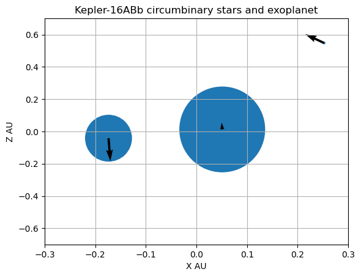

```python
au = [149600000000, 149600000000, 149600000000] # creating a numpy array with equal length to the x and z arrays with 1 au in meters in all three locations
au = np.array(au)

# I googled, " how to convert a list of strings to a list of floats
x_float = [float(s) for s in x]
z_float = [float(s) for s in z]
mass_float = [float(s) for s in mass]


massive = [1371800000000000000000000000000, 1371800000000000000000000000000, 1371800000000000000000000000000]
massive = np.array(massive)
#print(type(mass), type(massive))


scaler = (mass_float / massive *10000) #scaling them with the largest mass
scale = scaler.tolist()
#print(scale)

#converting into au
x_au = x_float/au
z_au = z_float/au
#print(len(x_au), len(z_au), len(scale))

#creating velocity floats for the velocity vectors
vx_float = [float(s) for s in vx]
vz_float = [float(s) for s in vz]
#print(vx_float)
#print(vz_float)


plt.scatter(x_au,z_au, s=scale) # there are 1.496e+11 meters in an AU
plt.quiver(x_au,z_au,vx_float,vz_float) #adding in the velocity vectors
plt.xlim(-0.3,0.3)
plt.ylim(-0.7,0.7)
plt.grid()
plt.xlabel("X AU")
plt.ylabel("Z AU")
plt.title("Kepler-16ABb circumbinary stars and exoplanet")
```

## 9 Use your N-body code to calculate the planet and stars’ orbits. Evolve the system for a total of 500 days, using a time step of Δ𝑡 = 0.5 days

[figure not shown]

```python
import matplotlib.animation as ani
FFMpegWriter = ani.writers['ffmpeg']
writer = FFMpegWriter(fps=10)

fig = plt.figure(figsize=(7, 7))
fig.patch.set_alpha(1.0) # Python bug fix... still

# Write plots to frames of an animation
with writer.saving(fig, "ecc_vec.mp4", 10):

    for i in range(0,len(time_array)):

        plt.quiver([0, 0], [0, 0], positions[i, :, 0], positions[i, :, 1], color=["blue", "orange"], scale=1)

        plt.xlim(-0.4, 0.4); plt.ylim(-0.4, 0.4);
        plt.xlabel(r'$e_x$'); plt.ylabel(r'$e_y$');
        plt.title(f'Eccentricity Vector at time = {time_array[i]:02.2f}')

        writer.grab_frame()

        plt.cla()
```

```python
#getting the libraries for animation
import matplotlib.animation as ani #importing the animation module for matplotlib
writer = ani.ImageMagickWriter(fps=5) # create a movie writer object, and set the frames/second to 5
fig.patch.set_alpha(1.0) # Python bug fix... still

# create a figure, 5x5 in size
```

```python
c = ["yellow", "red", "brown"] #I googled, "kepler-16 ABb star color" for the colors of the stars and the planet Kepler-16 system


# defining each object's x-z positions
keplerA = [x_au[0], z_au[0]]
keplerB = [x_au[1], z_au[1]]
keplerb = [x_au[2], z_au[2]]

keplerAv = [vx_float[0], vz_float[0]]
keplerBv = [vx_float[1], vz_float[1]]
keplerbv = [vx_float[2], vz_float[2]]


position9 = [[keplerA, keplerB, keplerb]] #making a new list for the positions
velocity9 = [[keplerAv, keplerBv, keplerbv]] #making a new list for the velocities

print(len(position9[-1]))
print(len(position9[-1]))


day = 0 # defining the starting day
delta_day = 0.5 #defining the change in days each run


fig = plt.figure(figsize=(7, 7))
fig.patch.set_alpha(1.0) # Python bug fix... still

with writer.saving(fig, 'Kepler-16ABb.mp4', 10):

    while day <= 5:
        print(day)
        if day == 0:
            print(day)
            plt.scatter(x_au,z_au, s=scale) # there are 1.496e+11 meters in an AU
            plt.quiver(x_au,z_au,vx_float,vz_float) #adding in the velocity vectors
            plt.xlim(-0.3,0.3)
            plt.ylim(-0.7,0.7)
            plt.grid()
            plt.xlabel("X AU")
            plt.ylabel("Z AU")
            plt.title("Kepler-16ABb circumbinary stars and exoplanet")
        else:

            display = False
            print(f"{position9[-1]}, \t, {len(velocity9[-1])}, \t {len(mass_float)}")
            calculateTrajectories(position9[-1], velocity9, force, mass_float, delta_t, start_t, end_t, display)
            position9.append(position[-1])
            velocity9.append(velocity[-1])
            print(f"position9[-1] = {position9[-1]}")
            print(f"velocity9[-1] = {velocity9[-1]}")

        day += delta_day #incrementing day by delta time
        writer.grab_frame()
```

```
3
3
```

[output not shown]

[output cut: 66 more lines]

[output not shown]

```python
display = False
#print(f"{(position9[-1])} \n \n {velocity9[-1]} \n \n {mass_float}")


#making mass list  the same length as the position9 list by adding the mass to both positions
mass_list = []

for i in range(len(position[0])):
    for j in range(len(position[0][i])):
        mass_list.append(mass_float[i])

print(mass_list)
calculateTrajectories(position9[-1], velocity9[-1], force, mass_list, delta_t, start_t, end_t, display)
#position9.append(position[-1])
#velocity9.append(velocity[-1])
#print(f"position9[-1] = {position9[-1]}")
#print(f"velocity9[-1] = {velocity9[-1]}")
```

## 12 Visualize your four-dimensional (𝑥, 𝑦, 𝑧, 𝑡) results in some manner that captures all four dimensions

For this, I will make a 3d animation using what was covered in lecture 23

Below is the code from lecture 23

```python
#code I will base my 3d plotting off from lecture 23
from mpl_toolkits import mplot3d

fig = plt.figure(figsize=(6,6))
ax = plt.axes(projection='3d')

ax.set_xlabel('x')
ax.set_ylabel('y')
ax.set_zlabel('t')
ax.zaxis.labelpad=-2 # sets the z-axis label position

# Data for a three-dimensional line
tline = np.linspace(0, 15, 1000)
xline = np.sin(tline)
yline = np.cos(tline)
ax.plot(xline, yline, tline, 'gray')

# Data for three-dimensional scattered points
tdata = 15 * np.random.random(100)
tdata.sort()
xdata = np.sin(tdata) + 0.1 * np.random.randn(100)
ydata = np.cos(tdata) + 0.1 * np.random.randn(100)
ax.scatter(xdata, ydata, tdata, c=tdata, cmap='coolwarm')
```

[output not shown]

```python
#code I will base my 3d plotting off from lecture 23
from mpl_toolkits import mplot3d

fig = plt.figure(figsize=(6,6))
ax = plt.axes(projection='3d')

ax.set_xlabel('x')
ax.set_ylabel('y')
ax.set_zlabel('time')
ax.zaxis.labelpad=-2 # sets the z-axis label position

# Earth
tline = time_array
Earthx = position_array[:, 0, 0]
Earthy = position_array[:, 0, 1]
Earthz = position_array[:, 0, 2]
ax.scatter(Earthx, Earthy, tline, 'blue')

# Sun
tline = time_array
Sunx = position_array[:, 1, 0]
Suny = position_array[:, 1, 1]
Sunz = position_array[:, 1, 2]
ax.scatter(Sunx, Suny, tline, 'yellow')
print(len(tline))
```

[output not shown]

```python
import matplotlib.animation as ani
FFMpegWriter = ani.writers['ffmpeg']
writer = FFMpegWriter(fps=10)

fig = plt.figure(figsize=(7, 7))
fig.patch.set_alpha(1.0) # Python bug fix... still

# Write plots to frames of an animation
with writer.saving(fig, "ecc_vec.mp4", 150):

    for i in range(0,len(time_array)):

        plt.quiver([0, 0], [0, 0], position_array[i, :, 0], position_array[i, :, 1], color=["blue", "orange"], scale=1)

        plt.xlim(-0.4, 0.4); plt.ylim(-0.4, 0.4);
        plt.xlabel(r'$e_x$'); plt.ylabel(r'$e_y$');
        plt.title(f'Eccentricity Vector at time = {time_array[i]:02.2f}')

        writer.grab_frame()

        plt.cla()
```

```python
#from IPython.display import Video
#Video("ecc_vec.mp4", embed=True)
```

```
407
0
1296000
```

[figure not shown]

```python
#demo code from lecture 23 for 3d animation
import matplotlib.animation as ani
FFMpegWriter = ani.writers['ffmpeg']
writer = FFMpegWriter(fps=10)

fig = plt.figure(figsize=(7, 7))
fig.patch.set_alpha(1.0) # Python bug fix... still

from mpl_toolkits import mplot3d






ax = plt.axes(projection='3d')

ax.view_init(45)
#setting the labels
ax.set_xlabel('x-distance from sun in AU')
ax.set_ylabel('y-distance from sun in AU')
ax.set_zlabel('Z-distance from sun in AU')
ax.zaxis.labelpad=-2 # sets the z-axis label position

ax.set_xlim([-1.1, 1.1])  # Set x-axis limits
ax.set_ylim([-1.1, 1.1])  # Set y-axis limits
ax.set_zlim([-1.1, 1.1])  # Set z-axis limits

earth_ratio = float(m_Earth/m_sun*1000)

print(len(time_array))
print(time_array[0])
print(time_array[1])






with writer.saving(fig, "Sun-Earth_3D.mp4", 500):

    for i in range(0,len(time_array)):





        ax.set_xlabel('x-distance from sun in AU')
        ax.set_ylabel('y-distance from sun in AU')
        ax.set_zlabel('Z-distance from sun in AU')
        ax.zaxis.labelpad=-2 # sets the z-axis label position

        ax.set_xlim([-1.1, 1.1])  # Set x-axis limits
        ax.set_ylim([-1.1, 1.1])  # Set y-axis limits
        ax.set_zlim([-1.1, 1.1])  # Set z-axis limits

        # Earth
        tline = time_array
        Earthx = position_array[i, 0, 0]
        Earthy = position_array[i, 0, 1]
        Earthz = position_array[i, 0, 2]


        # Sun
        tline = time_array
        Sunx = position_array[i, 1, 0]
        Suny = position_array[i, 1, 1]
        Sun = position_array[i, 1, 2]

        ax.scatter(Earthx, Earthy, Earthz, 'blue', label = 'the Earth')
        ax.scatter(Sunx, Suny, Sunz, 'yellow', label = 'the sun')
        plt.legend()
        writer.grab_frame()

        plt.cla()
```

```python
from IPython.display import Video
Video("/home/luel8892/ASTR 2600/Sun-Earth_3D.mp4", embed=True)
```

[video not shown]

## 11 Choose Your Own Adventure

On Canvas, Dr. AKiba has provided additional sets of initial conditions in .txt file form to have fun and explore.

```
Choose a set of initial conditions from among these options

Read in the appropriate data file (or make your own)

Then, calculate their trajectories
```

```python
from systems import planetesimalDisk#importing the tinyCluster function from system.py
```

```python
help(planetesimalDisk)
```

```
Help on function planetesimalDisk in module systems:

planetesimalDisk(num_of_particles=30, mass_ratio=1e-10, z_velocity=1000.0)
    This function creates N-body initial conditions for a (very) cartoon
    model of a disk of planetesimals (baby planets) orbiting around the
    star.

    At very small values, the gravity is totally dominated by the central
    star. At larger values (above about 1e-6, roughly an Earth mass per
    particle), the orbits may start to go unstable due to the interactions
    between the particles.

    The disk will be created mostly in the x-y plane, but you can add
    random velocities with a standard deviation set by z_velocity
    (in units of m/s) to perturb their orbits above and below the plane.

    Arguments
    ---------
        num_of_particles : int
            The total number of particles to create with the first particle
            being a solar-mass star

        mass_ratio : float
            The ratio of the mass of each planetesimal to the mass of the
            central star.

        z_velocity : float
            z-axis velocity standard deviation

    Returns
    -------
        masses, positions, velocities :
            masses 1D np.array whose shape is (nParticles)
            positions 2D np.array whose shape is (nParticles, nDimensions)
            velocities 2D np.array whose shape is (nParticles, nDimensions)
```

```python
mass10, pos10, vel10 = planetesimalDisk(num_of_particles = 10) #this shold generate 10 random particles then assigning the reuslts to mass10, pos10, vel10
```

```python
delta_t = 60 #setting delta_t to the number of seconds in a minute
start_t = 0 # settomg the start t to 0 seconds
end_t = 60*60 # setting the end time to 1 hours
display = False
time_array =np.linspace(start_t, end_t, delta_t+1)


calculateTrajectories(pos10, vel10, force, mass10, delta_t, start_t, end_t, display)
print(time_array)
```

```
[   0.   60.  120.  180.  240.  300.  360.  420.  480.  540.  600.  660.
  720.  780.  840.  900.  960. 1020. 1080. 1140. 1200. 1260. 1320. 1380.
 1440. 1500. 1560. 1620. 1680. 1740. 1800. 1860. 1920. 1980. 2040. 2100.
 2160. 2220. 2280. 2340. 2400. 2460. 2520. 2580. 2640. 2700. 2760. 2820.
 2880. 2940. 3000. 3060. 3120. 3180. 3240. 3300. 3360. 3420. 3480. 3540.
 3600.]
```

```python
position = np.array(position)
position = position/(1.496e+11) #converting the position into AU
```

```python
print(f" acceleration = {type(acceleration)} with length, {len(acceleration)} with elements, {acceleration}")
print(f" velocity = {type(velocity)} with length, {len(velocity)} with elements, {velocity}")
print(f" position = {type(position)} with length, {len(position)} with elements, {position}")
print(f" time = {type(time)} with length, {len(time)} with elements, {time}")
```

[output not shown]

[output cut: 1104 more lines]

```
  [ 3.68507094e-01  2.28449871e-01  2.58335649e-05]
  [-3.95006889e-01  9.07297936e-01  3.19831246e-06]
  ...
  [ 4.09877222e-01 -7.25036331e-01 -6.45260328e-07]
  [ 5.48431751e-01 -1.55541654e-01  6.42526194e-06]
  [ 4.23164490e-01  5.07357436e-01  6.27852251e-05]]

 [[ 1.80349986e-16 -1.65344407e-17  2.31308896e-21]
  [ 3.68497533e-01  2.28465292e-01  2.62641234e-05]
  [-3.95017901e-01  9.07293141e-01  3.25161766e-06]
  ...
  [ 4.09888618e-01 -7.25029888e-01 -6.56014664e-07]
  [ 5.48436068e-01 -1.55526430e-01  6.53234954e-06]
  [ 4.23153202e-01  5.07366850e-01  6.38316448e-05]]]
 time = <class 'list'> with length, 62 with elements, [0, 60, 120, 180, 240, 300, 360, 420, 480, 540, 600, 660, 720, 780, 840, 900, 960, 1020, 1080, 1140, 1200, 1260, 1320, 1380, 1440, 1500, 1560, 1620, 1680, 1740, 1800, 1860, 1920, 1980, 2040, 2100, 2160, 2220, 2280, 2340, 2400, 2460, 2520, 2580, 2…
```

```python
print(position[11][1][0])
print(position)
```

```
0.36897476283981656
[[[ 0.00000000e+00  0.00000000e+00  0.00000000e+00]
  [ 3.69079537e-01  2.27523881e-01 -0.00000000e+00]
  [-3.94346079e-01  9.07585344e-01  0.00000000e+00]
  ...
  [ 4.09193270e-01 -7.25422557e-01  0.00000000e+00]
  [ 5.48171941e-01 -1.56454831e-01  0.00000000e+00]
  [ 4.23841378e-01  5.06792106e-01  0.00000000e+00]]

 [[ 4.84418354e-20 -4.50135384e-21  0.00000000e+00]
  [ 3.69070015e-01  2.27539326e-01  4.30559867e-07]
  [-3.94357094e-01  9.07580558e-01  5.33052124e-08]
  ...
  [ 4.09204672e-01 -7.25416125e-01 -1.07543404e-08]
  [ 5.48176283e-01 -1.56439614e-01  1.07087748e-07]
  [ 4.23830103e-01  5.06801536e-01  1.04642073e-06]]

 [[ 1.93769936e-19 -1.79997311e-20  6.11605093e-26]
  [ 3.69060493e-01  2.27554771e-01  8.61119734e-07]
  [-3.94368109e-01  9.07575771e-01  1.06610425e-07]
  ...
  [ 4.09216074e-01 -7.25409693e-01 -2.15086808e-08]
  [ 5.48180626e-01 -1.56424398e-01  2.14175497e-07]
  [ 4.23818828e-01  5.06810965e-01  2.09284146e-06]]

 ...

 [[ 1.68714631e-16 -1.54745939e-17  2.09291136e-21]
  [ 3.68516654e-01  2.28434449e-01  2.54030064e-05]
  [-3.94995877e-01  9.07302730e-01  3.14500726e-06]
  ...
  [ 4.09865826e-01 -7.25042773e-01 -6.34505993e-07]
  [ 5.48427433e-01 -1.55556877e-01  6.31817434e-06]
  [ 4.23175778e-01  5.07348021e-01  6.17388053e-05]]

 [[ 1.74483789e-16 -1.60001867e-17  2.20116535e-21]
  [ 3.68507094e-01  2.28449871e-01  2.58335649e-05]
  [-3.95006889e-01  9.07297936e-01  3.19831246e-06]
  ...
  [ 4.09877222e-01 -7.25036331e-01 -6.45260328e-07]
  [ 5.48431751e-01 -1.55541654e-01  6.42526194e-06]
  [ 4.23164490e-01  5.07357436e-01  6.27852251e-05]]

 [[ 1.80349986e-16 -1.65344407e-17  2.31308896e-21]
  [ 3.68497533e-01  2.28465292e-01  2.62641234e-05]
  [-3.95017901e-01  9.07293141e-01  3.25161766e-06]
  ...
  [ 4.09888618e-01 -7.25029888e-01 -6.56014664e-07]
  [ 5.48436068e-01 -1.55526430e-01  6.53234954e-06]
  [ 4.23153202e-01  5.07366850e-01  6.38316448e-05]]]
```

```
61
0.0
60.0
 i = 0
 i = 60
 i = 120
 i = 180
 i = 240
 i = 300
 i = 360
 i = 420
 i = 480
 i = 540
 i = 600
 i = 660
 i = 720
 i = 780
 i = 840
 i = 900
 i = 960
 i = 1020
 i = 1080
 i = 1140
 i = 1200
 i = 1260
 i = 1320
 i = 1380
 i = 1440
 i = 1500
 i = 1560
 i = 1620
 i = 1680
 i = 1740
 i = 1800
 i = 1860
 i = 1920
 i = 1980
 i = 2040
 i = 2100
 i = 2160
```

[output cut: 9 more lines]

```
 i = 2760
 i = 2820
 i = 2880
 i = 2940
 i = 3000
 i = 3060
 i = 3120
 i = 3180
 i = 3240
 i = 3300
 i = 3360
 i = 3420
 i = 3480
 i = 3540
 i = 3600
```

[figure not shown]

```python
#demo code from lecture 23 for 3d animation
import matplotlib.animation as ani
FFMpegWriter = ani.writers['ffmpeg']
writer = FFMpegWriter(fps=10)

fig = plt.figure(figsize=(7, 7))
fig.patch.set_alpha(1.0) # Python bug fix... still

from mpl_toolkits import mplot3d






ax = plt.axes(projection='3d')

ax.view_init(45)
#setting the labels
ax.set_xlabel('x-distance in AU')
ax.set_ylabel('y-distance in AU')
ax.set_zlabel('Z-distance in AU')
ax.zaxis.labelpad=-2 # sets the z-axis label position

ax.set_xlim([-5e-19, 5e-10])  # Set x-axis limits
ax.set_ylim([-5e-19, 5e-10])  # Set y-axis limits
ax.set_zlim([-5e-19, 5e-10])  # Set z-axis limits

earth_ratio = float(m_Earth/m_sun*1000)

print(len(time_array))
print(time_array[0])
print(time_array[1])




xpos = []
ypos = []
zpos = []




with writer.saving(fig, "planetesimaldisk.mp4", 500):

    for i in range(0,len(time_array)):





        ax.set_xlabel('x-distance from sun in AU')
        ax.set_ylabel('y-distance from sun in AU')
        ax.set_zlabel('Z-distance from sun in AU')
        ax.zaxis.labelpad=-2 # sets the z-axis label position

        ax.set_xlim([-5e-10, 5e-10])  # Set x-axis limits
        ax.set_ylim([-5e-10, 5e-10])  # Set y-axis limits
        ax.set_zlim([-5e-10, 5e-10])  # Set z-axis limits

        #trying to get the x, y, z postions out of the position list with slicing
        #xpos.append(position[i][:][0])
        #ypos.append(position[i][:][1])
        #zpos.append(position[i][:][2])
        index = int(time_array[i])
        ax.scatter(position[i][0][0], position[i][0][1], position[i][0][1])


        writer.grab_frame()

        plt.cla()
        #if (i+1) % 60 == 0: #progress checker
        print(f" i = {index}") #checking to make sure it works
```

```python
from IPython.display import Video
Video("planetesimaldisk.mp4", embed=True)
```

[video not shown]

I was not able to finish my planetesimal disk simulation

```python
print("testing")
```

```
testing
```